# Intro to hypothesis testing

2023-02-15

## Hypothesizing about the beak length of penguins

Let’s say we recover a penguin from an oil spill. It’s important for us to know what species the penguin belongs to in order to give them the right treatment. Because of the oil spill, we can’t use their color to identify them. We do know, however, the length of their bill which is 28mm. We think the penguin might be an Adelie penguin. Using a hypothesis testing approach, with an alpha level of 0.05, test whether the penguin is likely to be Adelie or not based on their beak length.

### 1. State the null and alternate hypotheses

H<sub>0</sub>: The individual is typical of the Adelie bill length distribution H<sub>1</sub>: The individual is not typical of the Adelie bill length distribution

### 2. Determine the characteristics of the comparison distribution.

Obtain the mean and standard deviation for the Adelie penguins. There are multiple correct ways to do this!

```r
penguins %>%
  filter(species == "Adelie")%>%
  summarize(mean = mean(bill_length_mm, na.rm = TRUE),
            sd = sd(bill_length_mm, na.rm = TRUE))
```

```
## # A tibble: 1 × 2
##    mean    sd
##   <dbl> <dbl>
## 1  38.8  2.66
```

```r
# or :

mean <- mean(penguins$bill_length_mm[penguins$species == "Adelie"], na.rm = TRUE)
sd <- sd(penguins$bill_length_mm[penguins$species == "Adelie"], na.rm = TRUE)

# or :

adelie <- filter(penguins, species == "Adelie")
mean(adelie$bill_length_mm, na.rm = TRUE)
```

```
## [1] 38.79139
```

```r
sd(adelie$bill_length_mm, na.rm = TRUE)
```

```
## [1] 2.663405
```

### 3. Determine the critical values

#### 3.1. Is this a one tailed or two tailed test?

Two tailed

#### 3.2. Determine which amount of the probability distribution should fall on each end of the distribution

0.025 on each side, or cutpoints 0.025 and 0.975

#### 3.3. Calculate which test values (the critical values) correspond to these amounts of the probability distribution.

```r
qnorm(c(0.025, 0.975))
```

```
## [1] -1.959964  1.959964
```

#### 3.4. Modify the plot to show your critical values

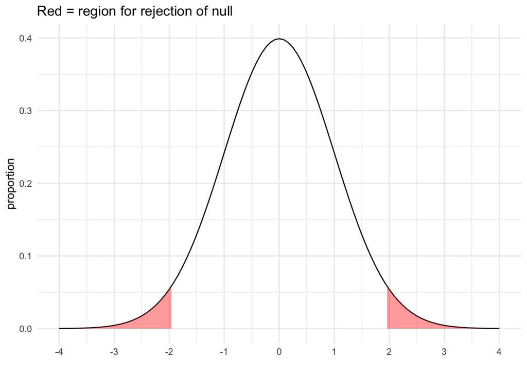

```r
ggplot(data = data.frame(x = c(-4, 4)), aes(x)) +
  stat_function(fun = dnorm, n = 101, args = list(mean = 0, sd = 1))+
  geom_area(stat = 'function', fun = dnorm, args = list(mean = 0, sd = 1), fill = "red", alpha = 0.4, xlim = c(-4, -1.96))+ # modify the xlim argument
  geom_area(stat = 'function', fun = dnorm, args = list(mean = 0, sd = 1), fill = "red", alpha = 0.4, xlim = c(4, 1.96))+ # modify the xlim argument
  scale_x_continuous(breaks = seq(-4,4,1))+ labs(x = "", y = "proportion")+
  theme_minimal()+
  ggtitle("Red = region for rejection of null")
```

### 4. Calculate the test value

#### 4.1. What is the value for your individual?

28mm

#### 4.2. Conduct the test:

```r
z <- (28-mean)/sd
z
```

```
## [1] -4.051728
```

#### 4.3. Copy and paste the plot code, and add a vertical line to show your test value - use `geom_vline()`

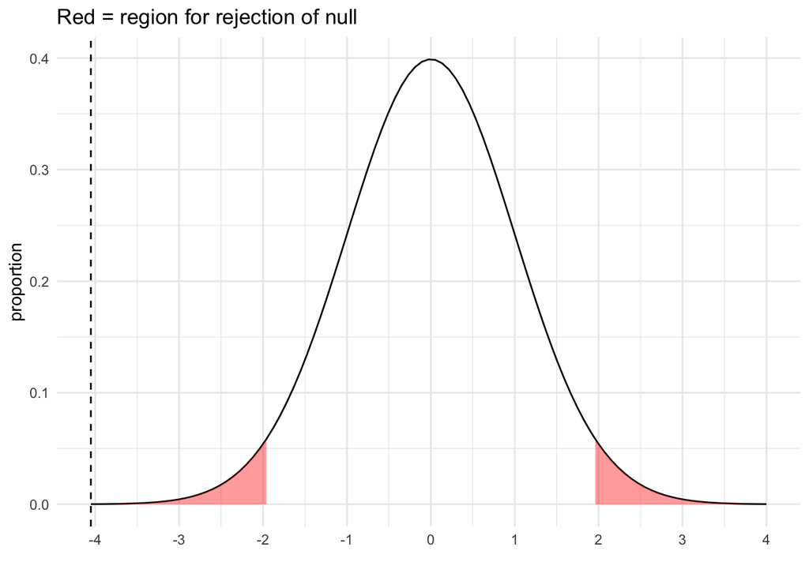

```r
ggplot(data = data.frame(x = c(-4, 4)), aes(x)) +
  stat_function(fun = dnorm, n = 101, args = list(mean = 0, sd = 1))+
  geom_area(stat = 'function', fun = dnorm, args = list(mean = 0, sd = 1), fill = "red", alpha = 0.4, xlim = c(-4, -1.96))+ # modify the xlim argument
  geom_area(stat = 'function', fun = dnorm, args = list(mean = 0, sd = 1), fill = "red", alpha = 0.4, xlim = c(4, 1.96))+ # modify the xlim argument
  scale_x_continuous(breaks = seq(-4,4,1))+ labs(x = "", y = "proportion")+
  geom_vline(xintercept = z, lty = "dashed")+
  theme_minimal()+
  ggtitle("Red = region for rejection of null")
```

### 5. Decide whether to reject the null

#### 5.1. State your conclusion

We reject the null, conluding that the penguin is not typical of the Adelie penguin species.